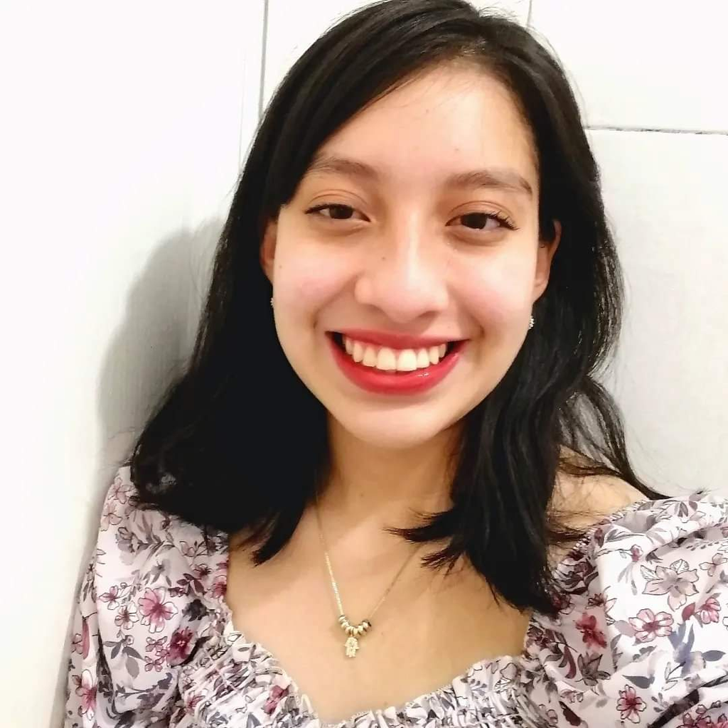

# **Karla Ximena González Platas**

## **💜 About myself**

I’m a Genomic Sciences student with a real passion for diving into the molecular mechanisms that make life tick. I love learning and am always eager to explore the next big thing in science.

I’ve got a strong interest in molecular biology, but I’m still figuring out exactly where I want to focus my research. Transcriptional regulation is one area that really grabs my attention, but I’m also super into astrobiology and studying extremophiles. These organisms are crucial for understanding how life can survive in the harshest environments—and maybe even what life might look like beyond Earth.

## **👩🏻‍🎓 Education**

**National Autonomous University of Mexico (UNAM)** | Morelos, MX

B.S. in Genomic Sciences [**LCG**](https://www.lcg.unam.mx/) | August 2023 - Present

**Antonio Audirac** | Puebla, MX

High School | August 2020 - July 2023

## **🔬 Research Experience**

**Center for Genomic Sciences, UNAM** | Synthetic Biology | Ayari Fuentes- Hernández Lab|Undergraduate researcher | February 2024 - July 2024

**Center for Genomic Sciences, UNAM** | Genomic Ecology | Esperanza Martínez-Romero | Undergraduate researcher | January 2024 - July 2024

## **📚 Teaching Experience**

Since 2023, I’ve been working as a biology teacher in the [**Admisión UNAM**](https://www.facebook.com/AdmisionaUNAM/about) course. In this role, I collaborate with fellow university students to help prepare young learners who are striving to gain admission to some of the top universities in the country. Teaching is one of the things I love doing most—it’s an opportunity to share my passion for knowledge and be part of my students’ growth and development.

## **💌 Interests and Hobbies**

I love painting 🎨, writing ✍️, science communication 🔬, programming 💻, music 🎻, and volleyball 🏐.

*I’m always looking for new opportunities to grow, collaborate, and share science.*